# ESM 244 - HW 4 - Task 2

Author

Lauren Puffer

## Overview

### Purpose of text analysis

By conducting a word count and sentiment analysis with the character data taken from the viral “Am I A Lesbian - Masterdoc,” I aim to detail the unique perspective of this author and observe the conclusions they draw based on the words they use, how often they are used, and whether or not they are associated with positive or negative sentiments. The AIAL masterdoc, originally a Google Doc shared on Tumblr by the user Cyberlesbian in 2018, has since been republished across various platforms as a PDF and continues to circulate the internet. Thousands of young people read this document when it was first posted, motivated by self-discovery, entertainment, and curiosity. Based on the most commonly used words, we will infer whether the conclusions drawn in this document are more rooted in the author’s aversion to being in a heterosexual relationship or their attraction to women. I must mention that the author of this document is a lesbian, and the conclusions they draw as to what makes someone a lesbian are based on their opinion.

[figure not shown]

{courtesy of Sarah Chuang of The Michigan Daily: https://www.michigandaily.com/statement/the-lesbian-master-doc-not-just-for-lesbians/}

### Citation

Lux, A. (2018, January). *Am I A Lesbian*. tumblr. https://www.docdroid.net/N46Ea3o/copy-of-am-i-a-lesbian-masterdoc-pdf

### Pseudocode

1. Bring in pdf of “Am I a Lesbian_ Masterdoc”
2. Mutate the data to individual lines in the document
3. Extract tokens (individual words)
4. Get rid of “stop words” and extract word count
5. Find the top 20 most used words in the entire doc
   - repeat for just the Table of Contents
6. Get sentiments of words using “bing” lexicon for positive/negative classification
7. Put words and their sentiments in order and group by page number.
8. Give pages a sentiment score (positive - negative) and plot sentiment scores to find the most negative or positive pages in the document.

## Load packages

```r
library(tidyverse)
library(tidytext) #allows us to clean up text data
library(pdftools) #allows us to bring in pdf of masterdoc
library(textdata)
library(here) #for file management
```

## Data wrangling

### Mutate into lines

In order to analyze each word in this document, we must first break it up line by line and unnest the text and trim the string data.

```r
#bring in text data
lesbian_text <- pdf_text(here('pdf', 'Am I a Lesbian_ Masterdoc.pdf'))

#each row is a page of the pdf and there are 31 pages making 31 rows

#split the data into stanzas
lesbian_lines <- data.frame(lesbian_text) |>
  mutate(page = 1:n()) |>
  mutate(text_full = str_split(lesbian_text, pattern = '\\n')) |>
  unnest(text_full) |>
  mutate(text_full = str_trim(text_full)) |>
  select(page, text_full)

#now we have a dataframe with page # and text
```

### Extracting “tokens”

Extracting tokens means pulling only words from the document. In order to get tokens, we must do some data wrangling with the stringr package.

```r
#extract only the tokens from the lesbian text file
lesbian_words <- lesbian_lines |>
  unnest_tokens(word, text_full) #get each word

#get a count of all words in the document
wordcount <- lesbian_words |>
  count(word)

#we want to get rid of filler or "stop words" by using antijoin()
lesbian_clean <- wordcount |>
  filter(word != "page") |> #remove the word 'page'
  filter(!str_detect(word, "[^[:alnum:]']")) |> #only keep alphanumerics
  anti_join(stop_words, by = 'word')
```

## Most freq. used words

To see what the primary content of this document consists of, we have extracted the top 20 words and plotted them with the word count.

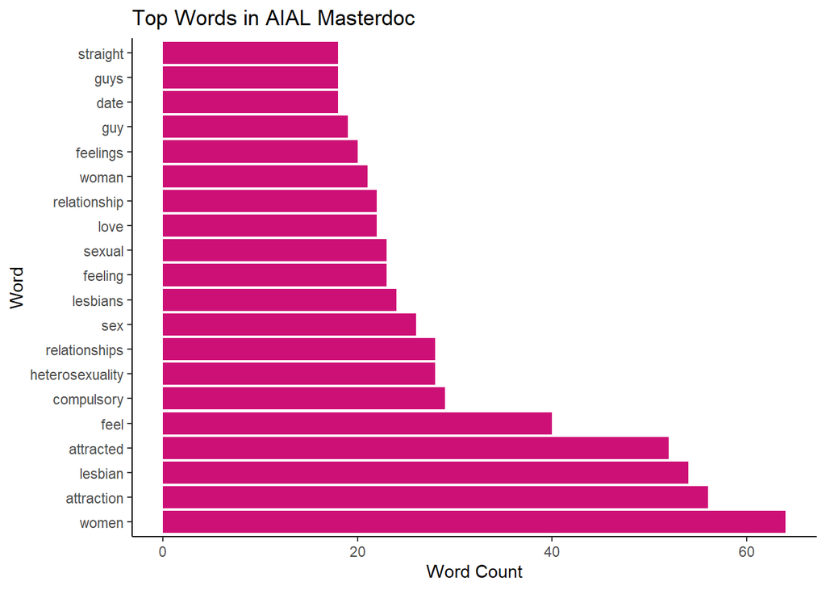

Fig. 1 - The 20 most used words in the Am I A Lesbian (AIAL) Masterdoc in descending order.

```r
#get the 20 most used words
top_20_words <- lesbian_clean |>
  arrange(-n) |>
  slice(1:20)

#bar graph with most freq used owrds
lesbar <- ggplot(data = top_20_words, aes(x = n, y = reorder(word, -n))) +
  geom_col( fill = "deeppink3")+
  labs(x = "Word Count", y = "Word", title = "Top Words in AIAL Masterdoc") +
  theme_classic()

print(lesbar)
```

With the top three words being “women,” “attraction,” and “lesbian,” it seems that the actual content of this masterdoc is focused more on the attraction that one feels towards women, rather than the discomfort a lesbian would feel when confronted with the idea of a heterosexual relationship.

### Contrast with Table of Contents

The table of contents of this masterdoc tells a different story from the words represented in the entire document. To illustrate this, we will make another bar chart with the top 5 words mentioned in the table of contents on the first page.

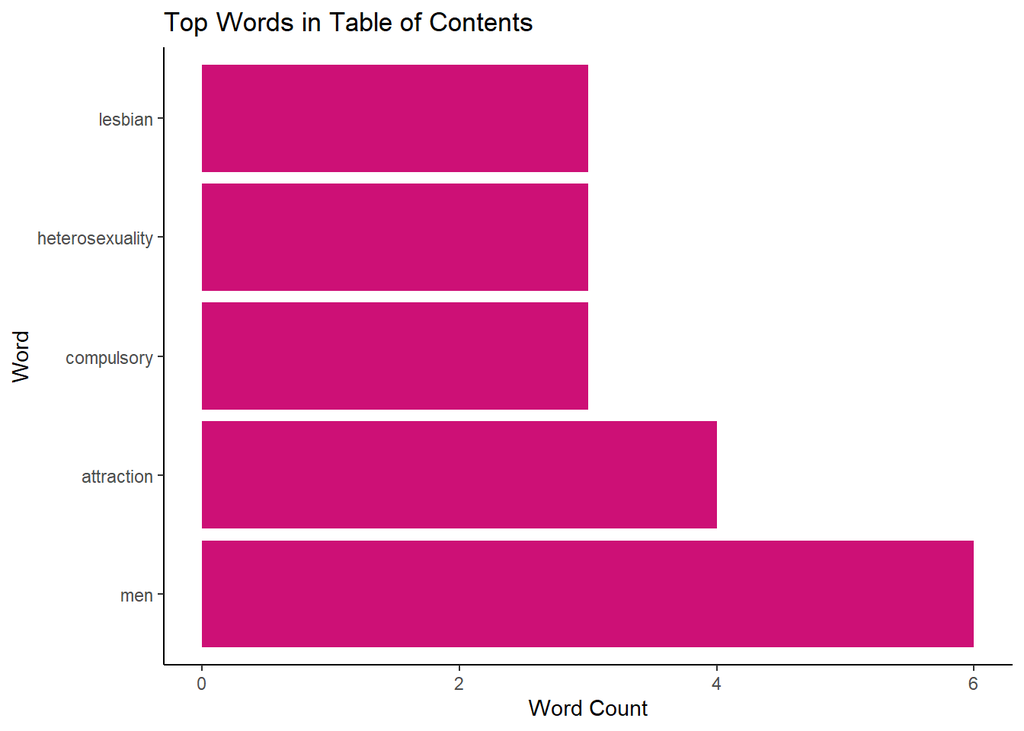

Fig. 2 - The 5 most used words in the Am I A Lesbian (AIAL) Masterdoc table of contents in descending order.

```r
#'men' is listed as a stop word, so we must change that first
stop_words_custom <- stop_words |>
  filter(word != "men")


#get just words on the first page
page1_words <- lesbian_lines|>
  filter(page == 1)|>
  unnest_tokens(word, text_full) |> #only extract words
    anti_join(stop_words_custom, by = 'word') #do away with stop words

#get top 5 words
page1_top5 <- page1_words |>
  count(word)|>
  arrange(-n) |>
  slice(1:5)

#plot the top 5
toc_bar <- ggplot(data = page1_top5, aes(x = n, y = reorder(word, -n))) +
  geom_col( fill = "deeppink3")+
  labs(x = "Word Count", y = "Word", title = "Top Words in Table of Contents") +
  theme_classic()

print(toc_bar)
```

As we can see, the top word in the table of contents was actually “men” despite this being a document intended to help the reader determine whether or not they are a lesbian. The table of contents seems to promise discussions of something called ‘compulsory heterosexuality’ and the readers feelings towards men. This mention of men I believe, is used in comparison with the feelings the reader may have about women.

## Sentiment analysis

To asses the tone of the author and the sentiment behind each of the words used, we will conduct a sentiment analysis. We will use the bing lexicon to identify sentiment associated with each word. This will tell us if a word is positive or negative. This association will not leave much room for interpretation, but it will make for an interesting comparison. We will be examining how the sentiment of the document changes from beginning to end.

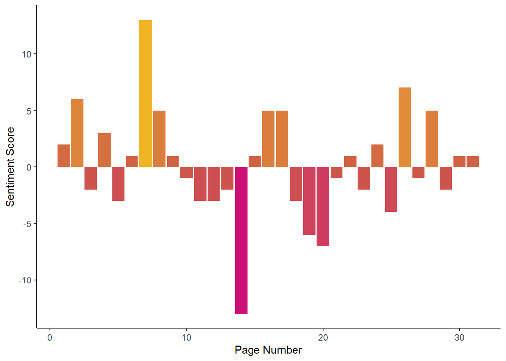

Fig. 3 - Sentiment scores of AIAL masterdoc based on number of positive minus number of negative words per page.

```r
#bring in bing lexicon
bing <- get_sentiments(lexicon = "bing")

#get data in order
lesbian_sentiment <- lesbian_words |>
  mutate(id = row_number()) |>
    anti_join(stop_words, by = 'word') |>
  arrange(id) |>
  select(-id)

#get bing associations for each word
lesbing <- lesbian_sentiment |>
  inner_join(bing, by = 'word')

#counts of bing
lesbing_count <- lesbing |>
  count(page,sentiment)

#group by page and plot
lesbing_plot <- lesbing_count |>
  group_by(page, sentiment) |> #group by page and sentiment type
  summarize(sentiment_count = sum(n), .groups = "drop") |>#summarize counts by sentiment
  spread(sentiment, sentiment_count, fill = 0) |>
  mutate(sentiment_score = positive - negative) |> #calculate sentiment score
  ggplot(aes(page, sentiment_score, fill = sentiment_score)) +
  geom_col(show.legend = FALSE) +
  labs(x = "Page Number", y = "Sentiment Score") +
  scale_fill_gradient2(low = "deeppink3", mid = "coral3", high = "goldenrod2", midpoint = 0)+
  theme_classic()

print(lesbing_plot)
```

The amount of negative words increased significantly on page 14. This page begins a subsection called “S*x and Intimacy with men.” I believe the reason for the negative sentiment score on this page is that the author is describing why none of these things appeal to her. This is likely because the author is a lesbian. This is one of the instances where the masterdoc becomes more about the author’s aversion to being in a heterosexual relationship rather than their attraction to women, which again are both valid.

## Discussion

Anjeli Lux (AKA Cyberlesbian) stirred the world wide web with their detailed analysis of what they believed made someone a lesbian. Anjeli certainly did a lot of generalizing, which was no doubt harmful in hindsight, but this masterdoc is regarded with humor and nostalgia by those who read it 7 years ago. People still read this document, although it doesn’t receive quite the amount of attention it did in 2018. This document spurred interesting conversations between tumblr users of the time about sexuality, preference, and identity, but the strong opinions illustrated in this document have no real evidence to ground them that isn’t anecdotal. Much of the criticism of this masterdoc involves Anjeli’s take on heterosexual experiences, their tendency to impose their opinions, and their oversimplification of the dynamics and experiences that govern human sexuality. **Ultimately, this document is only representative of Anjeli’s experiences and there are no set of attributes that make any one person more or less of a lesbian aside from their own preferences.** Further qualitative analysis with survey data could be conducted to compare the experiences of other lesbian identifying individuals with Anjeli’s and get their opinions on this masterdoc.